# Cuantificación del mimetismo vocal heteroespecífico mediante aprendizaje profundo: evidencia en el pájaro campana

## Entrenamiento de los modelos

[figure not shown]

[figure not shown]

[figure not shown]

[figure not shown]

[figure not shown]

[figure not shown]

[figure not shown]

[figure not shown]

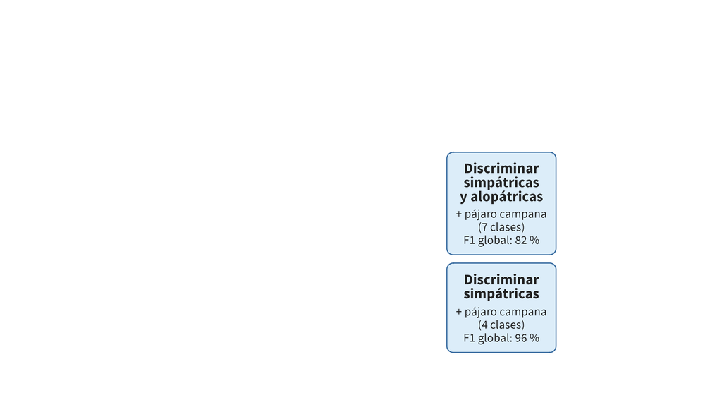

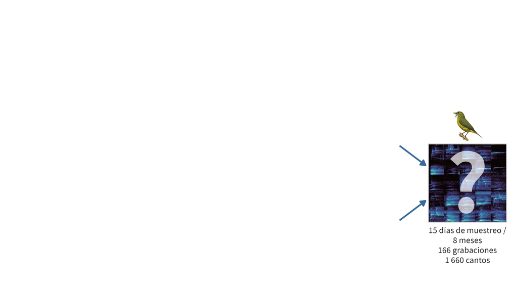

## Semejanza a simpátricas vs alopátricas

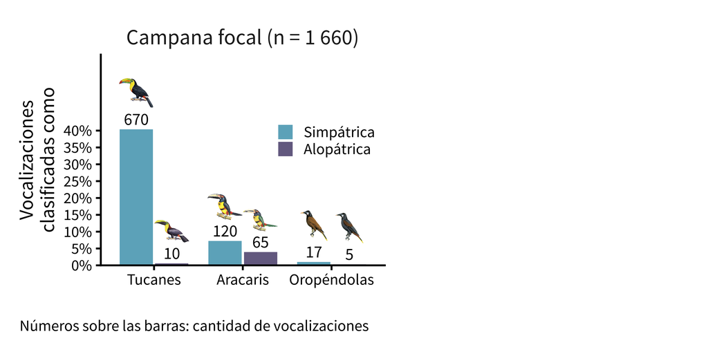

Campana focal: simpátricas 10 veces más que alopátricas  
Otros campanas: clasificados por modelos que nunca escucharon sus grabaciones

## Semejanza a simpátricas vs alopátricas

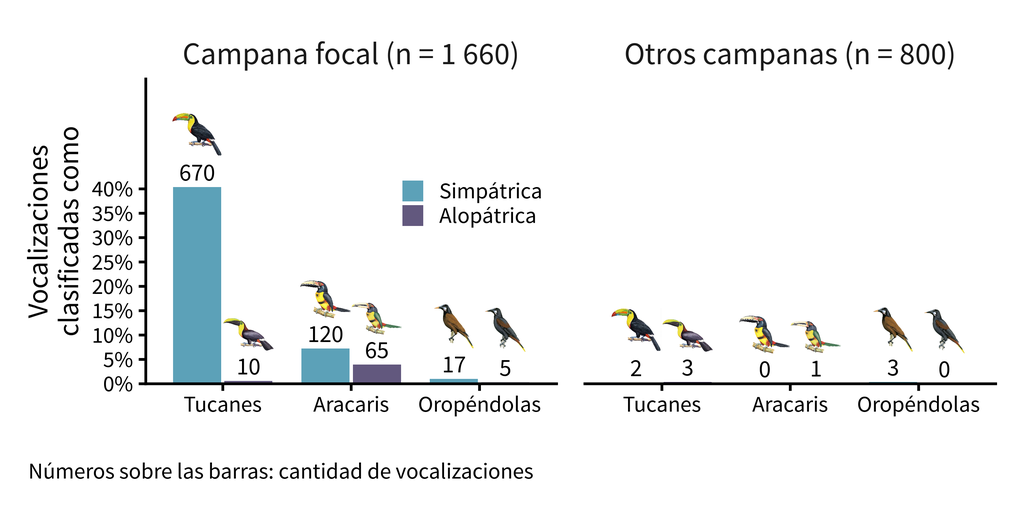

Campana focal: simpátricas 10 veces más que alopátricas  
Otros campanas: clasificados por modelos que nunca escucharon sus grabaciones

## Semejanza a simpátricas

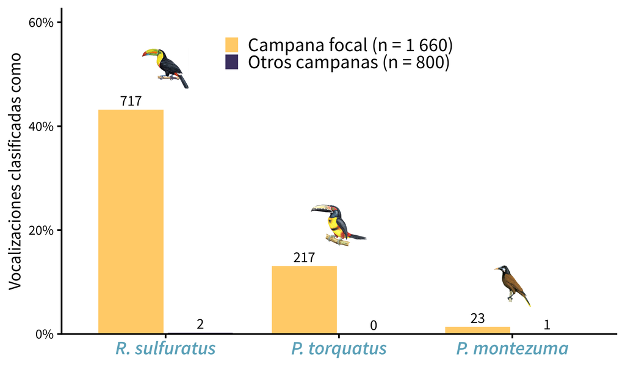

## Cambio en el tiempo

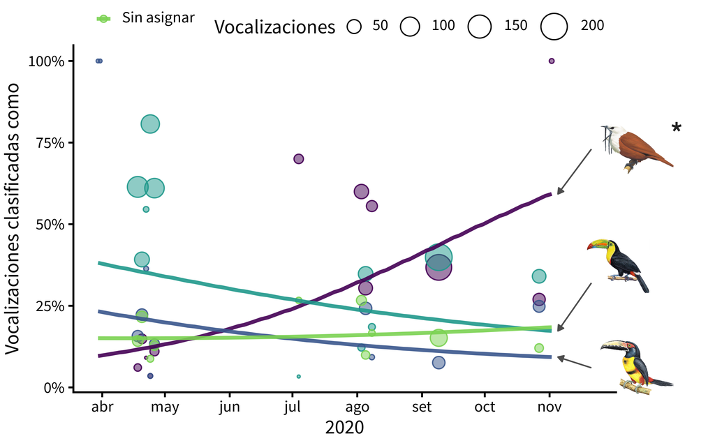

## Implicaciones

**Aprendizaje**  
Evidencia adicional de aprendizaje de la producción vocal en campanas

**Complejidad**  
Desarrollo vocal comparable en complejidad al de aves canoras

El mimetismo podría ser un componente **transitorio** del desarrollo vocal

## Agradecimientos y recursos

**Financiamiento**: Centro de Investigación en Neurociencias, Universidad de Costa Rica

**Ilustraciones de aves**: Birds of the World (Cornell Lab of Ornithology)

**Fotos**: David Jimenez

**Sitio del proyecto**: análisis, código y esta presentación  
[marce10.github.io/bellbird_vocal_mimicry](https://marce10.github.io/bellbird_vocal_mimicry/)

[figure not shown]

**suwo**: grabaciones de repositorios en línea desde R  
[docs.ropensci.org/suwo](https://docs.ropensci.org/suwo/)

[figure not shown]

**BirdNET**: identificación de aves por sonido con aprendizaje profundo  
[birdnet.cornell.edu](https://birdnet.cornell.edu/)

[figure not shown]

**dynaSpec**: los espectrogramas con sonido de esta presentación  
[marce10.github.io/dynaSpec](https://marce10.github.io/dynaSpec/)

Referencias

[figure not shown]

Esta presentación

## Referencias

1. BirdLife International y Handbook of the Birds of the World (2025). Bird species distribution maps of the world. Versión 2025.2.
2. Dalziell, A. H., Welbergen, J. A., Igic, B. y Magrath, R. D. (2015). Avian vocal mimicry: a unified conceptual framework. *Biological Reviews* 90: 643–668.
3. Jarvis, E. D. (2004). Learned birdsong and the neurobiology of human language. *Annals of the New York Academy of Sciences* 1016: 749–777.
4. Kahl, S., Wood, C. y Klinck, H. (2025). BirdNET Model V2.4. Zenodo.
5. Kelley, L. A., Coe, R. L., Madden, J. R. y Healy, S. D. (2008). Vocal mimicry in songbirds. *Animal Behaviour* 76: 521–528.
6. Kroodsma, D. E. et al. (2013). Behavioral evidence for song learning in the suboscine bellbirds (*Procnias* spp.; Cotingidae). *The Wilson Journal of Ornithology* 125: 1–14.
7. McTavish, E. J. et al. (2025). A complete and dynamic tree of birds. *Proceedings of the National Academy of Sciences*.
8. Saranathan, V., Hamilton, D., Powell, G. V. N., Kroodsma, D. E. y Prum, R. O. (2007). Genetic evidence supports song learning in the three-wattled bellbird *Procnias tricarunculata*. *Molecular Ecology* 16: 3689–3702.
9. Ten Cate, C. (2021). Re-evaluating vocal production learning in non-oscine birds. *Philosophical Transactions of the Royal Society B* 376: 20200249.

← Volver a recursos

## Discriminar simpátricas + alopátricas

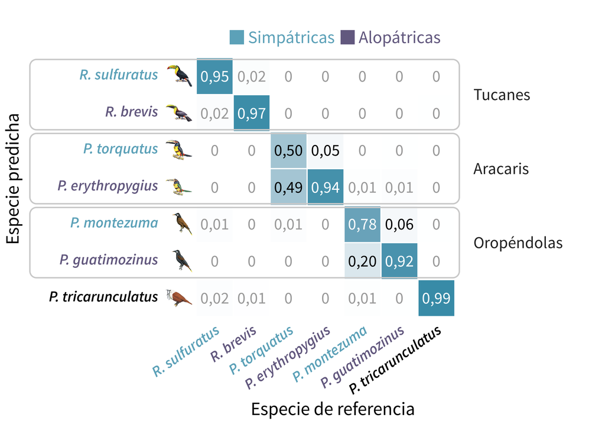

5 517 vocalizaciones, validación cruzada de 5 grupos (cada una clasificada por un modelo que nunca escuchó su grabación)

## Discriminar simpátricas

[figure not shown]